# Preparing a Cell Ranger ARC-Compatible Reference Genome

Irina Kuznetsova

2026-07-10

##### 0.0.0.0.1 Tutorial is written by PASQUALE LUCA CURCI

# 1 Overview

This vignette shows how to prepare a barley reference genome compatible with Cell Ranger ARC using `scShardSplitRef`.

Cell Ranger ARC cannot handle FASTA sequences longer than `2^29` bp (536,870,912 bp). Large chromosomes must therefore be split before running `cellranger-arc mkref`.

This vignette is written as a complete case study because reference preparation is often species- and repository-specific. In this example:

- nuclear FASTA and GTF files are taken from Ensembl Plants release 63;
- mitochondrial and plastid FASTA/GTF records are taken from Ensembl Plants release 48;
- centromere coordinates are taken from GrainGenes.

The generic `scShardSplitRef` workflow starts once we have prepared:

1. a combined FASTA;
2. a combined GTF;
3. a BED-like table with chromosome name, centromere position, and chromosome size.

Reference preparation workflow

```
Ensembl Plants (rel. 63)
    ├── nuclear FASTA
    └── nuclear GTF

Ensembl Plants (rel. 48)
    ├── Mt FASTA
    ├── Pt FASTA
    └── GTF

GrainGenes
    └── centromere positions

            │
            ▼

combined FASTA
combined GTF
centromere BED

            │
            ▼

determine_split_regions()

            │
            ▼

process_gtf()

            │
            ▼

bedtools getfasta

            │
            ▼

cellranger-arc mkref
```

# 2 Setup

```r
# remotes::install_github("IrinaVKuznetsova/scShardSplitRef")
# install.packages( c("dplyr", "tidyr") )
library(scShardSplitRef)
library(here)
library(Rsamtools)
library(dplyr)
library(readr)
library(stringr)
library(tidyr)
library(ggplot2)

data_dir <- here("data")
output_dir <- here("products")

dir.create(data_dir, recursive = TRUE, showWarnings = FALSE)
dir.create(output_dir, recursive = TRUE, showWarnings = FALSE)
```

Check required command-line tools.

```r
tools <- c("wget", "unzip", "zcat", "awk", "sed", "bedtools", "gzip")
missing_tools <- tools[!nzchar(Sys.which(tools))]

if (length(missing_tools) > 0) {
  stop("Missing tools: ", paste(missing_tools, collapse = ", "))
}
```

# 3 Case study-specific preprocessing

## 3.1 Download files

```r
hv_nucl_ep_rel_63 <- "https://ftp.ensemblgenomes.ebi.ac.uk/pub/plants/release-63/fasta/hordeum_vulgare/dna/Hordeum_vulgare.MorexV3_pseudomolecules_assembly.dna.toplevel.fa.gz"

hv_ep_rel_63_gtf <- "https://ftp.ensemblgenomes.ebi.ac.uk/pub/plants/release-63/gtf/hordeum_vulgare/Hordeum_vulgare.MorexV3_pseudomolecules_assembly.63.gtf.gz"

hv_mt_ep_rel_48 <- "https://ftp.ensemblgenomes.ebi.ac.uk/pub/plants/release-48/fasta/hordeum_vulgare/dna/Hordeum_vulgare.IBSC_v2.dna.chromosome.Mt.fa.gz"

hv_pt_ep_rel_48 <- "https://ftp.ensemblgenomes.ebi.ac.uk/pub/plants/release-48/fasta/hordeum_vulgare/dna/Hordeum_vulgare.IBSC_v2.dna.chromosome.Pt.fa.gz"

hv_ep_rel_48_gtf <- "https://ftp.ensemblgenomes.ebi.ac.uk/pub/plants/release-48/gtf/hordeum_vulgare/Hordeum_vulgare.IBSC_v2.48.gtf.gz"

hv_grain_genes_centromere_data <- "https://graingenes.org/GG3/sites/default/files/data_downloads/barley-morex3.zip"

cmd <- paste(
  "wget -P", shQuote(data_dir),
  shQuote(hv_nucl_ep_rel_63),
  shQuote(hv_ep_rel_63_gtf),
  shQuote(hv_mt_ep_rel_48),
  shQuote(hv_pt_ep_rel_48),
  shQuote(hv_ep_rel_48_gtf),
  shQuote(hv_grain_genes_centromere_data)
)

system(cmd)
```

Define local file paths.

```r
nuclear_fa <- file.path(data_dir, "Hordeum_vulgare.MorexV3_pseudomolecules_assembly.dna.toplevel.fa.gz")
mt_fa <- file.path(data_dir, "Hordeum_vulgare.IBSC_v2.dna.chromosome.Mt.fa.gz")
pt_fa <- file.path(data_dir, "Hordeum_vulgare.IBSC_v2.dna.chromosome.Pt.fa.gz")

morex_gtf <- file.path(data_dir, "Hordeum_vulgare.MorexV3_pseudomolecules_assembly.63.gtf.gz")
organelle_gtf <- file.path(data_dir, "Hordeum_vulgare.IBSC_v2.48.gtf.gz")

centromere_zip <- file.path(data_dir, "barley-morex3.zip")
```

## 3.2 Combine FASTA files

The nuclear genome is written first, followed by mitochondrial and plastid sequences.

```r
genome_fasta <- file.path(data_dir, "hv_combined.fa")

cmd <- paste(
  "zcat",
  shQuote(nuclear_fa),
  shQuote(mt_fa),
  shQuote(pt_fa),
  ">",
  shQuote(genome_fasta)
)

system(cmd)

stopifnot(file.exists(genome_fasta))
```

Index the combined FASTA and extract sequence sizes.

```r
fa <- Rsamtools::FaFile(genome_fasta)

if (!file.exists(paste0(genome_fasta, ".fai"))) {
  Rsamtools::indexFa(fa)
}
```

```
## class: FaFile
## path: /data/lucurci/projects/53_Irina/data/hv_combined.fa
## index: /data/lucurci/projects/53_Irina/data/hv_combined.fa.fai
## gzindex: /data/lucurci/projects/53_Irina/data/hv_combined.fa.gzi
## isOpen: FALSE
## yieldSize: NA
```

```r
idx <- Rsamtools::scanFaIndex(fa)

chr_sizes <- data.frame(
  chr = as.character(seqnames(idx)),
  size_bp = width(idx)
)

head(chr_sizes)
```

```
##   chr   size_bp
## 1  1H 516505932
## 2  2H 665585731
## 3  3H 621516506
## 4  4H 610333535
## 5  5H 588218686
## 6  6H 561794515
```

## 3.3 Prepare centromere coordinates

```r
cmd <- paste(
  "unzip -o",
  shQuote(centromere_zip),
  "-d",
  shQuote(data_dir)
)

system(cmd)

hv_centromere <- Sys.glob(
  file.path(data_dir, "*", "*", "*", "MorexV3_centromere_positions.tsv")
)

stopifnot(length(hv_centromere) == 1)

centromere_bed <- file.path(data_dir, "hv_combined_centromeres.bed")

readr::read_delim(
  hv_centromere,
  col_names = c("chr", "centromere_pos"),
  show_col_types = FALSE
) |>
  mutate(chr = stringr::str_remove(chr, "^chr")) |>
  right_join(chr_sizes, by = "chr") |>
  mutate(centromere_pos = tidyr::replace_na(centromere_pos, 0L)) |>
  select(chr, centromere_pos, size_bp) |>
  readr::write_delim(
    file = centromere_bed,
    delim = "\t",
    col_names = FALSE
  )

stopifnot(file.exists(centromere_bed))
```

## 3.4 Combine GTF files

The MorexV3 release 63 GTF is used as the main annotation. Mitochondrial and plastid records are appended from release 48.

```r
gtf_path <- file.path(data_dir, "hv_combined.gtf")

# The release 48 GTF contains annotations for both nuclear and organellar sequences. Only mitochondrial and plastid annotations are retained and appended to the release 63 nuclear annotation.
cmd <- sprintf(
  "(zcat %s; zcat %s | awk '$1==\"Mt\" || $1==\"Pt\"') > %s",
  shQuote(morex_gtf),
  shQuote(organelle_gtf),
  shQuote(gtf_path)
)

system(cmd)

stopifnot(file.exists(gtf_path))
```

Check that `Mt` and `Pt` records are present.

```r
cmd <- sprintf(
  "awk '$1==\"Mt\" || $1==\"Pt\" {print $1}' %s | sort -u",
  shQuote(gtf_path)
)

system(cmd)
```

[output not shown]

# 4 Generic scShardSplitRef workflow

From this point onward, the workflow is generic and can be reused for other species, provided that equivalent FASTA, GTF, and centromere files are available.

```r
bed_path <- centromere_bed

split_bed_path <- file.path(output_dir, "B1_Split_regions.bed")
out_fasta <- file.path(output_dir, "B1_FASTA_split_FINAL.fasta")

stopifnot(
  file.exists(bed_path),
  file.exists(gtf_path),
  file.exists(genome_fasta)
)
```

# 5 Visualize chromosome sizes before splitting

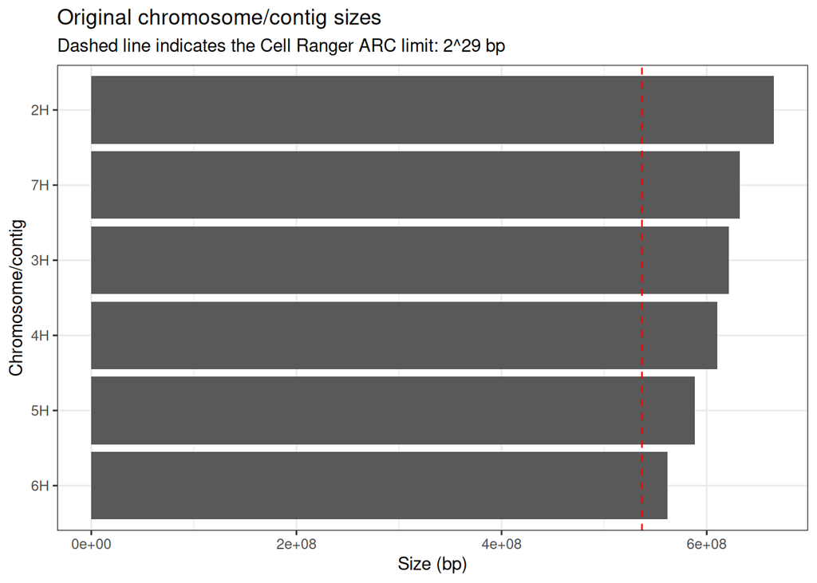

```r
cellranger_arc_limit <- 2^29

ggplot(chr_sizes |> filter(size_bp > 2^29),
       aes(x = reorder(chr, size_bp), y = size_bp)) +
  geom_col() +
  geom_hline(
    yintercept = cellranger_arc_limit,
    linetype = "dashed",
    colour = "red"
  ) +
  coord_flip() +
  labs(
    title = "Original chromosome/contig sizes",
    subtitle = "Dashed line indicates the Cell Ranger ARC limit: 2^29 bp",
    x = "Chromosome/contig",
    y = "Size (bp)"
  ) +
  theme_bw()
```

```r
chr_sizes |>
  filter(size_bp >= cellranger_arc_limit)
```

```
##   chr   size_bp
## 1  2H 665585731
## 2  3H 621516506
## 3  4H 610333535
## 4  5H 588218686
## 5  6H 561794515
## 6  7H 632540561
```

# 6 Generate split regions

```r
determine_split_regions(
  bed = bed_path,
  gtf = gtf_path,
  output_bed = split_bed_path,
  limit = 2L^29L,
  shift_by = 20L
)
```

```
## Preparing split regions from 'bed' and 'gtf' into 'output_bed' (`limit` =
## 536870912, `shift_by` = 20, `clearance` = 1).
## Built 299 split intervals across 292 chromosomes and wrote them to
## 'output_bed'.
```

```r
stopifnot(file.exists(split_bed_path))
```

# 7 Generate modified GTF

```r
process_gtf(
  split_regions_bed = split_bed_path,
  gtf = gtf_path,
  genome_name = "barley",
  genome_version = "MorexV3",
  out_path = output_dir
)
```

```
## ℹ Validating inputs and reading files...
```

```
## All files loaded and validated successfully.
## ℹ Finished writing processed GTF: /data/lucurci/projects/53_Irina/products/B1_FINAL_MODIFIED_GTF_barley_MorexV3.gtf
```

```r
modified_gtf <- file.path(
  output_dir,
  "B1_FINAL_MODIFIED_GTF_barley_MorexV3.gtf"
)

stopifnot(file.exists(modified_gtf))
```

# 8 Split FASTA using bedtools

```r
cmd <- paste(
  "bedtools getfasta",
  "-fi",
  shQuote(genome_fasta),
  "-bed",
  shQuote(split_bed_path),
  "| sed '/^>/s/:/-/g'",
  ">",
  shQuote(out_fasta)
)

system(cmd)

stopifnot(file.exists(out_fasta))
```

# 9 Validate final FASTA

```r
fa_split <- Rsamtools::FaFile(out_fasta)

if (!file.exists(paste0(out_fasta, ".fai"))) {
  Rsamtools::indexFa(fa_split)
}
```

```
## class: FaFile
## path: /data/lucurci/projects/53_Irina/products/B1_FASTA_split_FINAL.fasta
## index: /data/lucurci/projects/53_Irina/product.../B1_FASTA_split_FINAL.fasta.fai
## gzindex: /data/lucurci/projects/53_Irina/produ.../B1_FASTA_split_FINAL.fasta.gzi
## isOpen: FALSE
## yieldSize: NA
```

```r
idx_split <- Rsamtools::scanFaIndex(fa_split)

split_chr_sizes <- data.frame(
  chr = as.character(seqnames(idx_split)),
  size_bp = width(idx_split)
)

split_chr_sizes |>
  arrange(desc(size_bp)) |>
  head()
```

```
##                      chr   size_bp
## 1 5H-204878572-588218686 383340114
## 2 2H-301293086-665585731 364292645
## 3 3H-267852507-621516506 353663999
## 4 4H-276149121-610333535 334184414
## 5         7H-0-328847192 328847192
## 6 1H-206486643-516505932 310019289
```

Check that no sequence remains above the Cell Ranger ARC limit.

```r
split_chr_sizes |>
  filter(size_bp >= cellranger_arc_limit)
```

```
## [1] chr     size_bp
## <0 rows> (or 0-length row.names)
```

# 10 Output files

The main output files are:

```r
c(
  split_regions_bed = split_bed_path,
  split_fasta = out_fasta,
  modified_gtf = modified_gtf
)
```

```
##                                                                   split_regions_bed
##                     "/data/lucurci/projects/53_Irina/products/B1_Split_regions.bed"
##                                                                         split_fasta
##               "/data/lucurci/projects/53_Irina/products/B1_FASTA_split_FINAL.fasta"
##                                                                        modified_gtf
## "/data/lucurci/projects/53_Irina/products/B1_FINAL_MODIFIED_GTF_barley_MorexV3.gtf"
```

These files can be used to build a Cell Ranger ARC reference.

# 11 Cell Ranger ARC config example

```r
config_path <- file.path(output_dir, "03_cellranger_arc_barley.config")

config <- paste0(
  "{\n",
  '  "organism": "barley",\n',
  '  "genome": ["MOREX3_split"],\n',
  '  "input_fasta": ["', out_fasta, '"],\n',
  '  "input_gtf": ["', modified_gtf, '"],\n',
  '  "non_nuclear_contigs": ["Mt-0-525599", "Pt-0-115974"]\n',
  "}\n"
)

writeLines(config, config_path)

config_path
```

```
## [1] "/data/lucurci/projects/53_Irina/products/03_cellranger_arc_barley.config"
```

# 12 Build the reference with cellranger

```r
# Build the reference
cellranger_arc <- "/usr/local/bin/cellranger-arc"

mkref_log <- file.path(output_dir, "mkref.log")

exit_status <- system2(
   cellranger_arc,
  args = c(
    "mkref",
    paste0("--config=", config_path),
    "--nthreads=12"
  ),
  stdout = mkref_log,
  stderr = mkref_log
)

if (exit_status != 0) {
  stop("cellranger-arc mkref failed. Check log: ", mkref_log)
}
```

# 13 Optional cleanup

```r
file.remove(
  nuclear_fa,
  mt_fa,
  pt_fa,
  morex_gtf,
  organelle_gtf
)
```